# Ensemble Models - Classification

Ensemble methods improve prediction accuracy by combining the outputs of multiple base models. Bagging (Bootstrap Aggregation) reduces variance by averaging over bootstrapped trees (e.g., Random Forests), while Boosting sequentially builds trees that correct previous errors to reduce bias (e.g., Gradient Boosting).

### Strengths

- Excellent predictive performance
- Reduces variance and bias depending on method
- Handles large and high-dimensional datasets well
- Variable importance measures are available

### Weaknesses

- Models are harder to interpret
- Computationally intensive
- Requires careful tuning of model hyperparameters

### Overview

In this note, we examine voting models, bag, random forest, and various boosting models. Next, we tune hyperparameters for these models. All these models are designed to address classification problems.

## Clicks Data

This dataset describes user interactions with online advertisements for a digital marketing platform. It includes demographic, behavioral, and contextual features for 2000 users, along with whether each user clicked on an ad. The goal is to predict whether a person clicked on an ad.

### Read Data

- Import data
- Separate Features from the Outcome, click

```python
import pandas as pd
clicks = pd.read_csv('clicks.csv')
clicks.head()
```

|  | click | age | gender | device | browser | time_on_site | pages_visited | ad_position | ad_type | is_weekend | user_logged_in | past_click_rate | ad_relevance_score |
| --- | --- | --- | --- | --- | --- | --- | --- | --- | --- | --- | --- | --- | --- |
| 0 | 0 | 50 | 2 | 2 | 1 | 211 | 1 | 3 | 4 | 1 | 1 | 0.069 | 7 |
| 1 | 0 | 57 | 1 | 1 | 3 | 251 | 4 | 2 | 3 | 0 | 1 | 0.043 | 6 |
| 2 | 1 | 68 | 1 | 1 | 2 | 222 | 2 | 2 | 1 | 0 | 1 | 0.073 | 9 |
| 3 | 0 | 30 | 2 | 2 | 1 | 206 | 2 | 1 | 1 | 0 | 1 | 0.147 | 4 |
| 4 | 0 | 60 | 2 | 1 | 2 | 183 | 6 | 2 | 3 | 0 | 1 | 0.183 | 5 |

```python
X = clicks.drop(['click'], axis=1)
y = clicks.click
```

```python
import numpy as np
import pandas as pd
import matplotlib.pyplot as plt

from sklearn.model_selection import train_test_split
from sklearn.metrics import accuracy_score, roc_auc_score
from sklearn.tree import DecisionTreeClassifier
```

### Split Data

- Use stratified sampling to ensure the proportion of clicks is approximately equal across two samples
- Assign 70% observations to train and remaining to test.

```python
X_train_raw, X_test_raw, y_train, y_test = train_test_split(X,y,
                                                    train_size=0.7,
                                                    stratify=y,
                                                    random_state=617)
```

### Transform

- Nominal categorical features need to transformed before use in a predictive model.
- Each categorical feature with k levels is represented by k-1 dummy variables.

```python
X_train_raw.head()
```

|  | age | gender | device | browser | time_on_site | pages_visited | ad_position | ad_type | is_weekend | user_logged_in | past_click_rate | ad_relevance_score |
| --- | --- | --- | --- | --- | --- | --- | --- | --- | --- | --- | --- | --- |
| 1797 | 42 | 1 | 2 | 2 | 211 | 2 | 1 | 1 | 0 | 1 | 0.049 | 9 |
| 292 | 51 | 2 | 2 | 1 | 253 | 3 | 2 | 3 | 1 | 0 | 0.080 | 3 |
| 858 | 27 | 2 | 1 | 1 | 96 | 2 | 1 | 2 | 0 | 0 | 0.108 | 6 |
| 682 | 54 | 1 | 1 | 2 | 208 | 6 | 2 | 4 | 0 | 0 | 0.001 | 5 |
| 1183 | 30 | 1 | 2 | 2 | 220 | 3 | 3 | 3 | 0 | 1 | 0.131 | 7 |

```python
categorical_features = ['gender', 'device', 'browser','ad_position', 'ad_type','is_weekend', 'user_logged_in']

X_train = pd.get_dummies(X_train_raw,
                         columns=categorical_features,
                         drop_first=True)

X_test = pd.get_dummies(X_test_raw,
                        columns=categorical_features,
                        drop_first=True).reindex(columns=X_train.columns, fill_value=0)

X_train.head()
```

|  | age | time_on_site | pages_visited | past_click_rate | ad_relevance_score | gender_2 | gender_3 | device_2 | device_3 | browser_2 | browser_3 | browser_4 | browser_5 | ad_position_2 | ad_position_3 | ad_type_2 | ad_type_3 | ad_type_4 | is_weekend_1 | user_logged_in_1 |
| --- | --- | --- | --- | --- | --- | --- | --- | --- | --- | --- | --- | --- | --- | --- | --- | --- | --- | --- | --- | --- |
| 1797 | 42 | 211 | 2 | 0.049 | 9 | False | False | True | False | True | False | False | False | False | False | False | False | False | False | True |
| 292 | 51 | 253 | 3 | 0.080 | 3 | True | False | True | False | False | False | False | False | True | False | False | True | False | True | False |
| 858 | 27 | 96 | 2 | 0.108 | 6 | True | False | False | False | False | False | False | False | False | False | True | False | False | False | False |
| 682 | 54 | 208 | 6 | 0.001 | 5 | False | False | False | False | True | False | False | False | True | False | False | False | True | False | False |
| 1183 | 30 | 220 | 3 | 0.131 | 7 | False | False | True | False | True | False | False | False | False | True | False | True | False | False | True |

## Ensemble Model

An ensemble model predictions of multiple individual models to produce a final prediction that is typically more accurate, robust, and stable than any single model. It works best when models are diverse, and predictions are independent and uncorrelated.

### Fit Individual Models

```python
from sklearn.tree import DecisionTreeClassifier
from sklearn.linear_model import LogisticRegression
from sklearn.ensemble import VotingClassifier

logit = LogisticRegression(max_iter=1000000, random_state=617)
logit.fit(X_train, y_train)


tree = DecisionTreeClassifier(random_state=617)
tree.fit(X_train, y_train)
```

```
DecisionTreeClassifier(random_state=617)
```

### Performance

```python
classifiers = [('Logit',logit),
              ('Tree',tree)]

for model_name, model in classifiers:
    model.fit(X_train, y_train)
    pred_test = model.predict(X_test)
    auc = accuracy_score(y_test, pred_test)
    print(model_name, auc)
```

```
Logit 0.7383333333333333
Tree 0.63
```

### Combine Models

For classification problems, predictions are aggregated by voting.

```python
vc = VotingClassifier(estimators=classifiers)
vc.fit(X_train, y_train)
pred_test = vc.predict(X_test)
auc = accuracy_score(y_test, pred_test)
auc
```

```
0.7366666666666667
```

## Bag

A bag model, short for Bootstrap Aggregating, aims to improve the stability and accuracy of predictions by fitting multiple models in parallel on random subsets of the data and then aggregating their predictions.

### with tree estimator

```python
%%time
from sklearn.ensemble import BaggingClassifier
bag = BaggingClassifier(n_estimators=200,
                        n_jobs = -1,
                        oob_score=True,
                        random_state=1031) # default estimator is DecisionTreeClassifier
bag.fit(X_train, y_train)
```

```
CPU times: total: 2.98 s
Wall time: 1min 45s
```

```
BaggingClassifier(n_estimators=200, n_jobs=-1, oob_score=True,
                  random_state=1031)
```

### Predict

Predictions of individual models are combined by voting.

```python
pred_train = bag.predict(X_train)
pred_test = bag.predict(X_test)
pred_train_prob = bag.predict_proba(X_train)
pred_test_prob = bag.predict_proba(X_test)
```

### Evaluate

```python
print('Train Accuracy: ', accuracy_score(y_train, pred_train))
print('Test Accuracy:  ', accuracy_score(y_test, pred_test))
print('Train Accuracy: ', roc_auc_score(y_train, pred_train_prob[:,1]))
print('Test Accuracy:  ', roc_auc_score(y_test, pred_test_prob[:,1]))
```

```
Train Accuracy:  1.0
Test Accuracy:   0.7133333333333334
Train Accuracy:  1.0
Test Accuracy:   0.68634321068056
```

```python
print('OOB Score: ', bag.oob_score_)
```

```
OOB Score:  0.7114285714285714
```

## Bag

### with logit estimator

```python
from sklearn.linear_model import LogisticRegression
logit = LogisticRegression(random_state = 1031)

bag = BaggingClassifier(estimator = logit,
                        n_estimators=200,
                        n_jobs = -1,
                        oob_score=True,
                        random_state=1031)
bag.fit(X_train, y_train)
```

```
BaggingClassifier(estimator=LogisticRegression(random_state=1031),
                  n_estimators=200, n_jobs=-1, oob_score=True,
                  random_state=1031)
```

### Predict

```python
pred_train = bag.predict(X_train)
pred_test = bag.predict(X_test)

pred_train_prob = bag.predict_proba(X_train)
pred_test_prob = bag.predict_proba(X_test)
```

### Evaluate

```python
print('Train Accuracy: ', accuracy_score(y_train, pred_train))
print('Test Accuracy:  ', accuracy_score(y_test, pred_test))
print('Train Accuracy: ', roc_auc_score(y_train, pred_train_prob[:,1]))
print('Test Accuracy:  ', roc_auc_score(y_test, pred_test_prob[:,1]))
```

```
Train Accuracy:  0.7385714285714285
Test Accuracy:   0.74
Train Accuracy:  0.761518087654731
Test Accuracy:   0.726616737219147
```

```python
print('OOB Score: ',bag.oob_score_)
```

```
OOB Score:  0.7285714285714285
```

## Random Forest

A Random Forest upon the concept of bagging (bootstrap aggregating) by training multiple decision trees on different random subsets of the data and features, and then combining their predictions to make a final decision. So, it is a special type of bag model that uses a random subset of features for each tree.

### with tree estimator

```python
%%time
from sklearn.ensemble import RandomForestClassifier
forest = RandomForestClassifier(n_estimators=200,
                                n_jobs = -1,
                                oob_score=True,
                                random_state=1031)
forest.fit(X_train, y_train)
```

```
CPU times: total: 1.44 s
Wall time: 850 ms
```

```
RandomForestClassifier(n_estimators=200, n_jobs=-1, oob_score=True,
                       random_state=1031)
```

### Predict

```python
pred_train = forest.predict(X_train)
pred_test = forest.predict(X_test)

pred_train_prob = forest.predict_proba(X_train)
pred_test_prob = forest.predict_proba(X_test)
```

### Evaluate

```python
print('Train Accuracy: ', accuracy_score(y_train, pred_train))
print('Test Accuracy:  ', accuracy_score(y_test, pred_test))
print('Train Accuracy: ', roc_auc_score(y_train, pred_train_prob[:,1]))
print('Test Accuracy:  ', roc_auc_score(y_test, pred_test_prob[:,1]))
```

```
Train Accuracy:  1.0
Test Accuracy:   0.7216666666666667
Train Accuracy:  1.0
Test Accuracy:   0.7050537284272224
```

```python
print('OOB Score: ',forest.oob_score_)
```

```
OOB Score:  0.7085714285714285
```

### Feature Importance

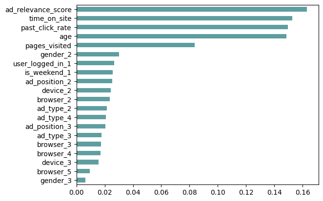

```python
pd.Series(forest.feature_importances_, index=X_train.columns)\
.sort_values(ascending=True)\
.plot(kind = 'barh', color = 'cadetblue')
plt.show()
```

## Boosting

A boosting model combines the predictions of multiple weak learners (typically shallow decision trees) to form a strong predictive model. Boosting works by training models sequentially, where each new model is trained to correct the errors made by the previous models.

## Adaboost

AdaBoost, short for Adaptive Boosting, is one of the earliest and most well-known boosting algorithms in machine learning. It builds a strong classifier by sequentially combining multiple weak learners, typically decision stumps (trees with only one split). Each subsequent model is trained by placing more emphasis (weight) on the instances that were misclassified by previous models.

### with Tree Estimator

```python
from sklearn.ensemble import AdaBoostClassifier
adaboost = AdaBoostClassifier(n_estimators = 100,
                              random_state = 1031,
                              algorithm = 'SAMME')  # default estimator is DecisionTreeClassifier
adaboost.fit(X_train, y_train)
```

```
AdaBoostClassifier(algorithm='SAMME', n_estimators=100, random_state=1031)
```

### Predict

```python
pred_train = adaboost.predict(X_train)
pred_test = adaboost.predict(X_test)

pred_train_prob = adaboost.predict_proba(X_train)
pred_test_prob = adaboost.predict_proba(X_test)
```

### Evaluate

```python
print('Train Accuracy: ', accuracy_score(y_train, pred_train))
print('Test Accuracy:  ', accuracy_score(y_test, pred_test))
print('Train Accuracy: ', roc_auc_score(y_train, pred_train_prob[:,1]))
print('Test Accuracy:  ', roc_auc_score(y_test, pred_test_prob[:,1]))
```

```
Train Accuracy:  0.7514285714285714
Test Accuracy:   0.7366666666666667
Train Accuracy:  0.7726367351227936
Test Accuracy:   0.7233539563660045
```

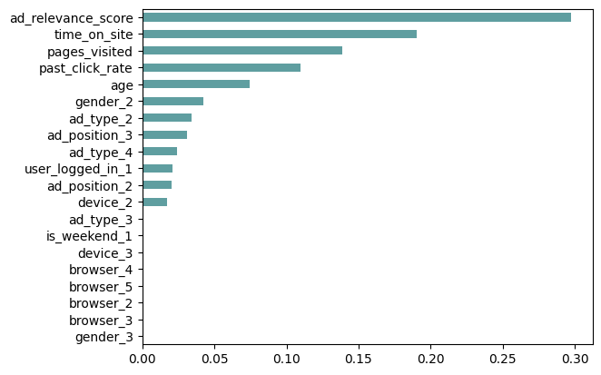

```python
pd.Series(adaboost.feature_importances_, index=X_train.columns)\
    .sort_values(ascending=True)\
    .plot(kind = 'barh', color = 'cadetblue')
plt.show()
```

## Gradient Boosting

Gradient Boosting builds a strong predictive model by sequentially adding weak learners (typically shallow decision trees), where each new learner is trained to minimize the error of the current ensemble using gradient descent. Unlike AdaBoost, which reweights observations, Gradient Boosting fits new models to the residual errors (the differences between actual and predicted values) by optimizing a loss function using gradients — hence the name “gradient” boosting.

```python
%time
from sklearn.ensemble import GradientBoostingClassifier
gb = GradientBoostingClassifier(n_estimators = 100,
                                random_state = 1031)
gb.fit(X_train, y_train)
```

```
CPU times: total: 0 ns
Wall time: 9.54 μs
```

```
GradientBoostingClassifier(random_state=1031)
```

### Predict

```python
pred_train = gb.predict(X_train)
pred_test = gb.predict(X_test)

pred_train_prob = gb.predict_proba(X_train)
pred_test_prob = gb.predict_proba(X_test)
```

### Evaluate

```python
print('Train Accuracy: ', accuracy_score(y_train, pred_train))
print('Test Accuracy:  ', accuracy_score(y_test, pred_test))
print('Train Accuracy: ', roc_auc_score(y_train, pred_train_prob[:,1]))
print('Test Accuracy:  ', roc_auc_score(y_test, pred_test_prob[:,1]))
```

```
Train Accuracy:  0.8307142857142857
Test Accuracy:   0.7283333333333334
Train Accuracy:  0.8961598811590811
Test Accuracy:   0.7182285900358191
```

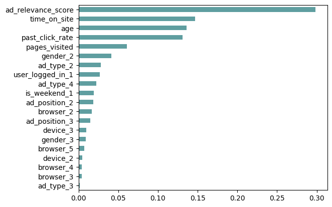

```python
pd.Series(gb.feature_importances_, index=X_train.columns)\
    .sort_values(ascending=True)\
    .plot(kind = 'barh', color = 'cadetblue')
plt.show()
```

## Stochastic Gradient Boosting

Stochastic Gradient Boosting is a variant of Gradient Boosting that introduces randomness into the boosting process to improve generalization and reduce overfitting.

In traditional gradient boosting, each weak learner is trained on the entire dataset to fit the residuals. In stochastic gradient boosting, each learner is instead trained on a random subsample of the data (typically without replacement). This makes the model more robust and faster, especially for large datasets.

```python
%%time
from sklearn.ensemble import GradientBoostingClassifier
sgb = GradientBoostingClassifier(n_estimators = 100,
                                 random_state = 617,
                                 max_features=0.2, # sample 20% of the features for each tree
                                 subsample=0.8)    # sample 80% of the data for each tree
sgb.fit(X_train, y_train)
```

```
CPU times: total: 250 ms
Wall time: 203 ms
```

```
GradientBoostingClassifier(max_features=0.2, random_state=617, subsample=0.8)
```

### Predict

```python
pred_train = sgb.predict(X_train)
pred_test = sgb.predict(X_test)

pred_train_prob = sgb.predict_proba(X_train)
pred_test_prob = sgb.predict_proba(X_test)
```

### Evaluate

```python
print('Train Accuracy: ', accuracy_score(y_train, pred_train))
print('Test Accuracy:  ', accuracy_score(y_test, pred_test))
print('Train Accuracy: ', roc_auc_score(y_train, pred_train_prob[:,1]))
print('Test Accuracy:  ', roc_auc_score(y_test, pred_test_prob[:,1]))
```

```
Train Accuracy:  0.8064285714285714
Test Accuracy:   0.745
Train Accuracy:  0.8650907188968047
Test Accuracy:   0.7228003907521979
```

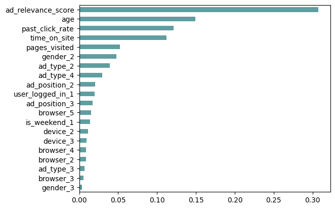

```python
pd.Series(sgb.feature_importances_, index=X_train.columns)\
    .sort_values(ascending=True)\
    .plot(kind = 'barh', color = 'cadetblue')
plt.show()
```

# Hyperparameter Tuning

## Tuned Forest

### Model for Tuning

```python
from sklearn.ensemble import RandomForestClassifier
forest = RandomForestClassifier(n_estimators=200,
                        n_jobs = -1,
                        oob_score=True,
                        random_state=1031)
forest.get_params()
```

```
{'bootstrap': True,
 'ccp_alpha': 0.0,
 'class_weight': None,
 'criterion': 'gini',
 'max_depth': None,
 'max_features': 'sqrt',
 'max_leaf_nodes': None,
 'max_samples': None,
 'min_impurity_decrease': 0.0,
 'min_samples_leaf': 1,
 'min_samples_split': 2,
 'min_weight_fraction_leaf': 0.0,
 'monotonic_cst': None,
 'n_estimators': 200,
 'n_jobs': -1,
 'oob_score': True,
 'random_state': 1031,
 'verbose': 0,
 'warm_start': False}
```

### Tune

```python
%%time
from sklearn.model_selection import GridSearchCV
param_grid = {'n_estimators':[200,500,1000],
             'max_features': [2, 3, 4, 5, 6, 7, 8, 9, 10, 12, 14, 16, 18, 20],
             'max_depth': [1, 2, 3, 4, 5, 6, 7, 8, 9, 10, 11, 12]}
tune_forest = GridSearchCV(estimator=forest,
                           param_grid=param_grid,
                           cv=5,
                           scoring ='roc_auc',
                           verbose = 1,
                           n_jobs=-1)
tune_forest.fit(X_train, y_train)
```

```
Fitting 5 folds for each of 504 candidates, totalling 2520 fits
CPU times: total: 8.62 s
Wall time: 15min 7s
```

```
GridSearchCV(cv=5,
             estimator=RandomForestClassifier(n_estimators=200, n_jobs=-1,
                                              oob_score=True,
                                              random_state=1031),
             n_jobs=-1,
             param_grid={'max_depth': [1, 2, 3, 4, 5, 6, 7, 8, 9, 10, 11, 12],
                         'max_features': [2, 3, 4, 5, 6, 7, 8, 9, 10, 12, 14,
                                          16, 18, 20],
                         'n_estimators': [200, 500, 1000]},
             scoring='roc_auc', verbose=1)
```

```python
tune_forest.best_params_
```

```
{'max_depth': 5, 'max_features': 2, 'n_estimators': 500}
```

```python
best_forest = tune_forest.best_estimator_
```

## Evaluate

```python
pred_train = best_forest.predict(X_train)
pred_test = best_forest.predict(X_test)

pred_train_prob = best_forest.predict_proba(X_train)
pred_test_prob = best_forest.predict_proba(X_test)

print('Train Accuracy: ', accuracy_score(y_train, pred_train))
print('Test Accuracy:  ', accuracy_score(y_test, pred_test))
print('Train Accuracy: ', roc_auc_score(y_train, pred_train_prob[:,1]))
print('Test Accuracy:  ', roc_auc_score(y_test, pred_test_prob[:,1]))
```

```
Train Accuracy:  0.6971428571428572
Test Accuracy:   0.6933333333333334
Train Accuracy:  0.8714244431123137
Test Accuracy:   0.7263432106805601
```

## Tuned Stochastic Gradient Boost

### Model for Tuning

```python
from sklearn.ensemble import GradientBoostingClassifier
sgb = GradientBoostingClassifier(random_state = 1031)
```

### Tune

```python
%%time
from sklearn.model_selection import GridSearchCV
param_grid = {'n_estimators':[100],
              'learning_rate': [0.01, 0.02, 0.03, 0.05, 0.06, 0.07, 0.08, 0.09],
              'max_depth': [1,2,3,4,5] ,
              'subsample':[0.5,0.6,0.8,1],
              'max_features': [1,2,3,4]}
tune_boost = GridSearchCV(estimator=sgb,
                           param_grid=param_grid,
                           cv=5,
                           scoring ='roc_auc',
                           verbose = 4,
                           n_jobs=-1)
tune_boost.fit(X_train, y_train)
```

```
Fitting 5 folds for each of 640 candidates, totalling 3200 fits
CPU times: total: 9.14 s
Wall time: 2min 10s
```

```
GridSearchCV(cv=5, estimator=GradientBoostingClassifier(random_state=1031),
             n_jobs=-1,
             param_grid={'learning_rate': [0.01, 0.02, 0.03, 0.05, 0.06, 0.07,
                                           0.08, 0.09],
                         'max_depth': [1, 2, 3, 4, 5],
                         'max_features': [1, 2, 3, 4], 'n_estimators': [100],
                         'subsample': [0.5, 0.6, 0.8, 1]},
             scoring='roc_auc', verbose=4)
```

```python
pd.DataFrame(tune_boost.cv_results_).head()
```

|  | mean_fit_time | std_fit_time | mean_score_time | std_score_time | param_learning_rate | param_max_depth | param_max_features | param_n_estimators | param_subsample | params | split0_test_score | split1_test_score | split2_test_score | split3_test_score | split4_test_score | mean_test_score | std_test_score | rank_test_score |
| --- | --- | --- | --- | --- | --- | --- | --- | --- | --- | --- | --- | --- | --- | --- | --- | --- | --- | --- |
| 0 | 0.309629 | 0.090554 | 0.006757 | 0.000231 | 0.01 | 1 | 1 | 100 | 0.5 | {'learning_rate': 0.01, 'max_depth': 1, 'max_f... | 0.750240 | 0.756024 | 0.704485 | 0.706420 | 0.730838 | 0.729601 | 0.021419 | 533 |
| 1 | 0.378071 | 0.034284 | 0.006417 | 0.000143 | 0.01 | 1 | 1 | 100 | 0.6 | {'learning_rate': 0.01, 'max_depth': 1, 'max_f... | 0.754375 | 0.760669 | 0.704425 | 0.712554 | 0.721696 | 0.730744 | 0.022625 | 509 |
| 2 | 0.265991 | 0.075029 | 0.006706 | 0.000350 | 0.01 | 1 | 1 | 100 | 0.8 | {'learning_rate': 0.01, 'max_depth': 1, 'max_f... | 0.753357 | 0.760879 | 0.700286 | 0.711304 | 0.728664 | 0.730898 | 0.023363 | 506 |
| 3 | 0.174102 | 0.061627 | 0.007171 | 0.000790 | 0.01 | 1 | 1 | 100 | 1.0 | {'learning_rate': 0.01, 'max_depth': 1, 'max_f... | 0.728333 | 0.738192 | 0.703532 | 0.718182 | 0.732089 | 0.724065 | 0.012152 | 592 |
| 4 | 0.160475 | 0.016351 | 0.007323 | 0.000889 | 0.01 | 1 | 2 | 100 | 0.5 | {'learning_rate': 0.01, 'max_depth': 1, 'max_f... | 0.746524 | 0.755454 | 0.710738 | 0.714043 | 0.735692 | 0.732490 | 0.017595 | 472 |

```python
tune_boost.best_params_
```

```
{'learning_rate': 0.06,
 'max_depth': 3,
 'max_features': 2,
 'n_estimators': 100,
 'subsample': 1}
```

[figure not shown]

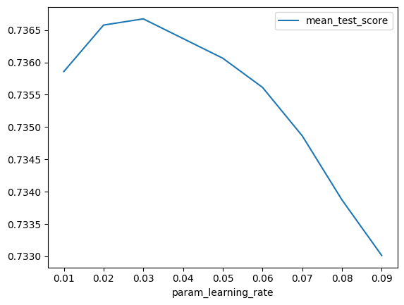

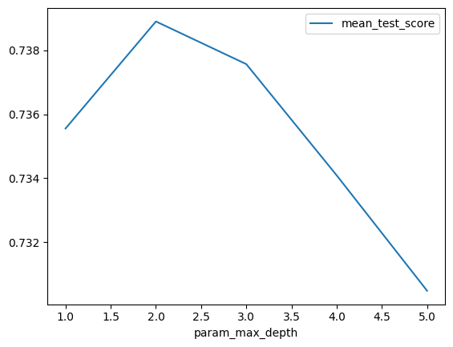

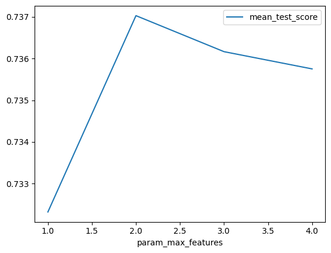

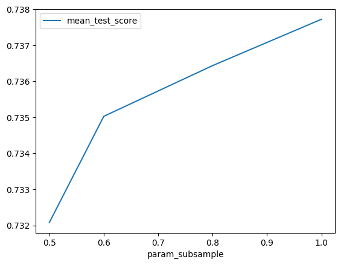

```python
cv_values = pd.DataFrame(tune_boost.cv_results_)
cv_values[['param_n_estimators', 'mean_test_score']].groupby('param_n_estimators').mean().plot()
cv_values[['param_learning_rate', 'mean_test_score']].groupby('param_learning_rate').mean().plot()
cv_values[['param_max_depth', 'mean_test_score']].groupby('param_max_depth').mean().plot()
cv_values[['param_max_features', 'mean_test_score']].groupby('param_max_features').mean().plot()
cv_values[['param_subsample', 'mean_test_score']].groupby('param_subsample').mean().plot()
plt.show()
```

```python
cv_values[['param_n_estimators','param_learning_rate','param_max_depth','param_max_features','param_subsample','mean_test_score']].\
sort_values('mean_test_score', ascending=False).head(15)
```

|  | param_n_estimators | param_learning_rate | param_max_depth | param_max_features | param_subsample | mean_test_score |
| --- | --- | --- | --- | --- | --- | --- |
| 359 | 100 | 0.06 | 3 | 2 | 1.0 | 0.751920 |
| 519 | 100 | 0.08 | 3 | 2 | 1.0 | 0.750805 |
| 599 | 100 | 0.09 | 3 | 2 | 1.0 | 0.750077 |
| 595 | 100 | 0.09 | 3 | 1 | 1.0 | 0.749917 |
| 515 | 100 | 0.08 | 3 | 1 | 1.0 | 0.749285 |
| 439 | 100 | 0.07 | 3 | 2 | 1.0 | 0.749281 |
| 279 | 100 | 0.05 | 3 | 2 | 1.0 | 0.748497 |
| 435 | 100 | 0.07 | 3 | 1 | 1.0 | 0.748125 |
| 199 | 100 | 0.03 | 3 | 2 | 1.0 | 0.747157 |
| 355 | 100 | 0.06 | 3 | 1 | 1.0 | 0.746843 |
| 294 | 100 | 0.05 | 4 | 2 | 0.8 | 0.746032 |
| 119 | 100 | 0.02 | 3 | 2 | 1.0 | 0.746030 |
| 275 | 100 | 0.05 | 3 | 1 | 1.0 | 0.745648 |
| 375 | 100 | 0.06 | 4 | 2 | 1.0 | 0.745534 |
| 41 | 100 | 0.01 | 3 | 3 | 0.6 | 0.745221 |

```python
best_boost = tune_boost.best_estimator_
```

#### Variable Importance

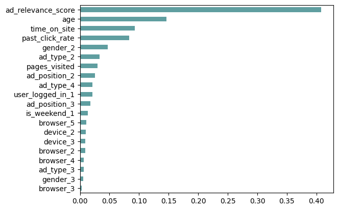

```python
pd.Series(best_boost.feature_importances_, index=X_train.columns)\
    .sort_values(ascending=True)\
    .plot(kind = 'barh', color = 'cadetblue')
plt.show()
```

## Evaluate

```python
pred_train = best_boost.predict(X_train)
pred_test = best_boost.predict(X_test)

pred_train_prob = best_boost.predict_proba(X_train)
pred_test_prob = best_boost.predict_proba(X_test)

print('Train Accuracy: ', accuracy_score(y_train, pred_train))
print('Test Accuracy:  ', accuracy_score(y_test, pred_test))
print('Train Accuracy: ', roc_auc_score(y_train, pred_train_prob[:,1]))
print('Test Accuracy:  ', roc_auc_score(y_test, pred_test_prob[:,1]))
```

```
Train Accuracy:  0.7721428571428571
Test Accuracy:   0.7483333333333333
Train Accuracy:  0.8324954443518322
Test Accuracy:   0.7204168023445131
```

## Summary

In this note, we examined voting models, bag, random forest, and various boosting models. We tuned hyperparameters for these models. All these models were designed to address classification problems.

```python
import platform
from IPython.display import display, HTML
import matplotlib
import sklearn as sklearn_complete
text = ('This file was generated using Python ' + platform.python_version() +\
      ' on a ' + platform.platform() + \
      ' system with Pandas ' + pd.__version__ + \
      ', Numpy ' + np.__version__ + \
      ', Matplotlib ' + matplotlib.__version__ + \
      ', Scikit-Learn ' + sklearn_complete.__version__ )

html = f"""
<hr style="border: 0; height: 1px; background: lightgray;" />
<p style="font-size: x-small; color: #555;">{text}</p>
"""

display(HTML(html))
```

This file was generated using Python 3.13.5 on a Windows-10-10.0.19045-SP0 system with Pandas 2.3.0, Numpy 2.3.1, Matplotlib 3.10.3, Scikit-Learn 1.7.1